# Generalized Linear Models 2

Joshua F. Wiley

2020-04-03

# 1 Setup

You can download the `R`markdown file for this content here https://jwiley.github.io/MonashHonoursStatistics/GLM2.rmd.

We will be using a few packages for this content and also the baseline data only from the data collection exercise.

```r
options(digits = 3)

library(haven)
library(data.table)
```

```r
library(JWileymisc)
library(ggplot2)
library(ggpubr)
library(visreg)
library(survey)
## read in data
db <- as.data.table(read_sav("B 19032020.sav")) # baseline

## create some binary variables
db[, StressHigh := as.integer(stress >= 31)]
db[, SelfesteemHigh := as.integer(selfesteem >= 15)]

## read in some example data from the internet
## (requires internet connection to run)
dcount <- fread("https://stats.idre.ucla.edu/stat/data/poisson_sim.csv")
```

# 2 Generalized Linear Models

We previously learned about linear regression and how it fit into the Generalized Linear Models (GLM) framework (if you are not clear on this, see: http://joshuawiley.com/MonashHonoursStatistics/GLM1.html).

Now we are going to learn about two other special cases of GLMs: binary logistic regression and poisson regression.

# 3 Poisson Regression

Poisson regression is used when the outcome is a count variable. Count variables are discrete and must be whole, 0 or positive numbers (e.g., 0, 1, 2, 3, etc.). The poisson distribution is used most often when the counts are relatively rare. Some examples of research use cases where a poisson may be appropriate are:

- examining risk factors for the number of accidents someone gets into over a 12 month period
- analysing the number of children people have
- predicting how many friends people have
- evaluating whether an intervention reduced the number of times someone missed their medication in the last month
- testing whether the total number of health care appointments over six months can be lowered by treating mental health

For count variables, it is common and not necessarily a problem if most people score a 0, with relatively few people having counts of 1, 2, 3, etc.

In the simulated `dcount` data we downloaded from the internet, there is a variable, `num_awards` which is the number of awards a student got. We can use `testDistribution()` to examine this and get a default comparison against a normal distribution as shown in the following figure. The density plot is “lumpy” showing the discrete nature of the data. No transformation would make this data approximately normally distributed.

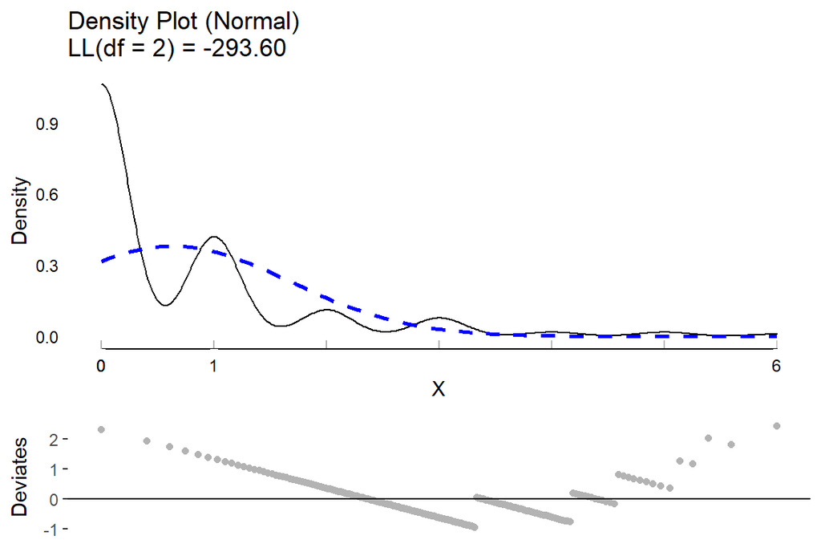

```r
plot(testDistribution(dcount$num_awards))
```

Rather than transform the data, we can change the distribution. We again use `testDistribution()` but this time specify the distribution as “poisson”. The poinsson distribution is a discrete distribution so a continuous density curve is not plotted. Instead, we get discrete bars where the solid dark grey bars show the observed density of different values and the blue bars show the density under a poisson distribution. The deviaties plot at the bottom again shows deviations from the assumed distribution, in this case, the poisson. Although the densities are not a perfect match, they are relatively close and we can see from the log likelihood values (labelled `LL`) printed in the graphs that the poisson has a **much** higher log likelihood for the data than does the normal distribution we tried earlier.

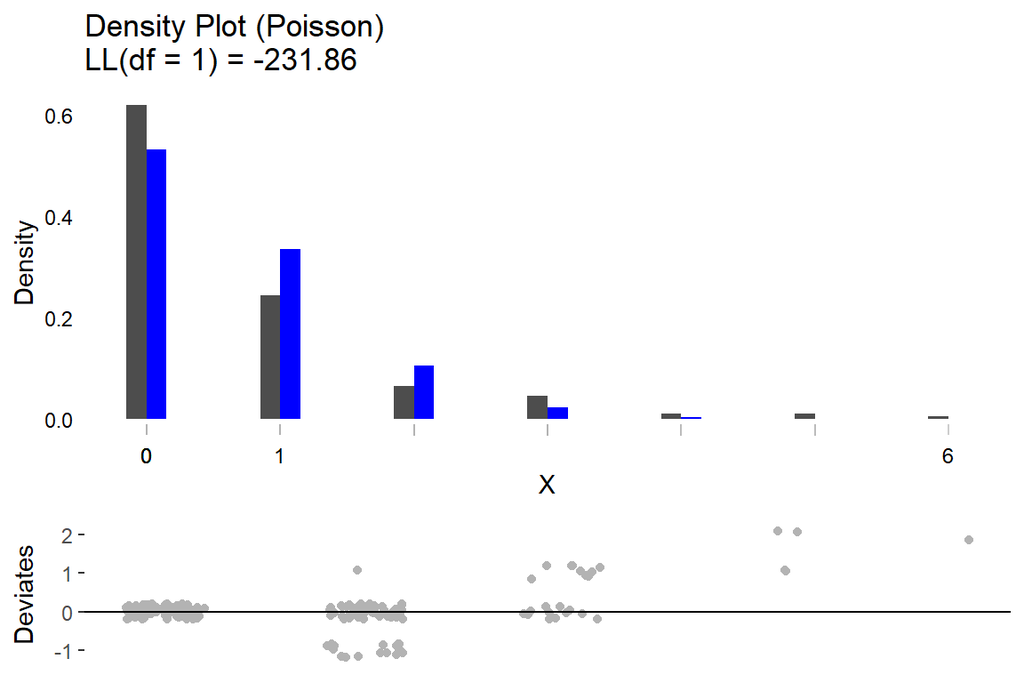

```r
plot(testDistribution(dcount$num_awards, distr = "poisson"))
```

Like the normal distribution, the poisson distribution is a family of distributions and the specific one you will get is controlled by a single parameter, $\lambda$, which is both the mean and the variance of the poisson distribution. You can find out more about the poisson distribution [here](https://en.wikipedia.org/wiki/Poisson_distribution) including the relevant equations for it. The figure that follows shows the density for different counts under a poisson distribution with varying $\lambda$ values.

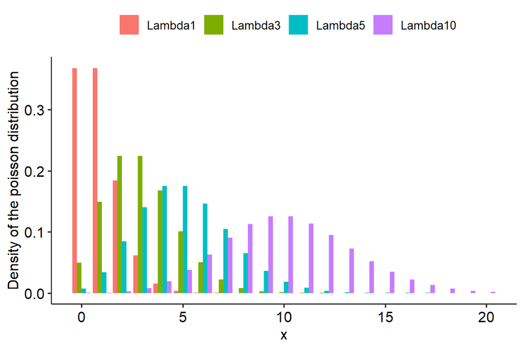

Linear regression rarely works well for count outcomes for two reasons:

- First, when an outcome can only be 0 or positive whole numbers, a straight line often is a bad fit and certainly at extremes (e.g., negative values) is impossible.
- Second, unless the average number of counts is fairly high, a count variable and its residuals will not follow anything approximating a normal distribution: the normality assumption would be violated.

The GLM solves each of these problems separately

- Link functions transform the linear predicted value $\eta$ so that it never goes below 0
- Rather than assume a normal distribution, the GLM can assume a poisson distribution
  - Whereas the Normal distribution had two parameters, mean and standard deviation, the poisson distribution only has one: the average which is the same as the variance, called $\lambda$

For poisson regression, the link function is defined as:

$$\eta = g(\lambda) = ln(\lambda)$$

where $ln()$ is the **n**atural **l**ogarithm (or log with base e, euler’s number).

Graphing $\lambda$ against $\lambda$ we get

Fig 1a. Average counts against average counts

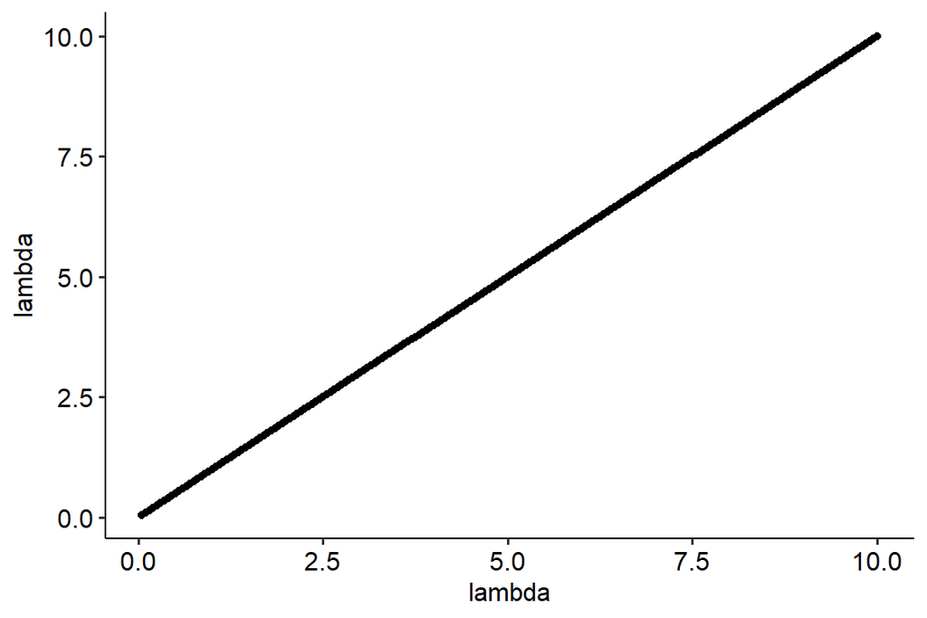

The link function, the natural logarithm, unbounds $\lambda$ on the left side because the log of 0 is negative infinity

The followinggraph shows the raw $\lambda$ values against the natural log transformed values.

Fig 1b. Average counts against log transformed average counts

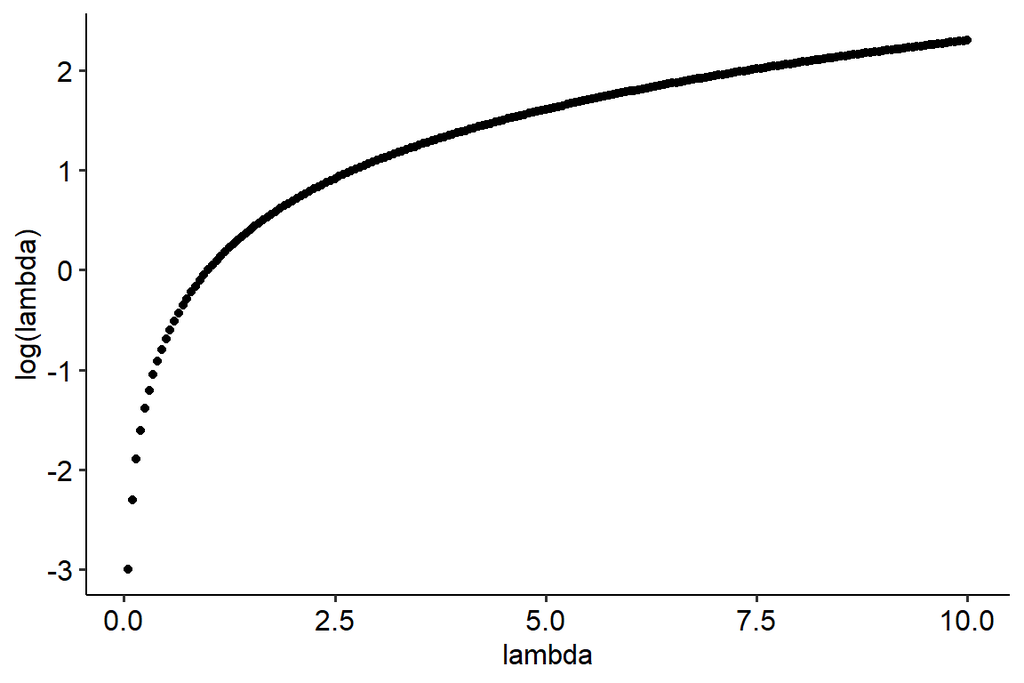

In this way, the link function for poisson regression takes the average number of counts, which can only fall > 0 and transforms it to fall between negative infinity and positive infinity

Now we have a continuous and unbounded outcome we can apply a linear model to!

To go from predictions on the linear model back to the original count scale, we use the inverse link function:

- $\lambda = g^{-1}(\eta) = e^{\eta}$

That is, suppose we had the linear predicted values, $\eta$ shown below graphically

Fig 2a. Linear predictor against linear predictor

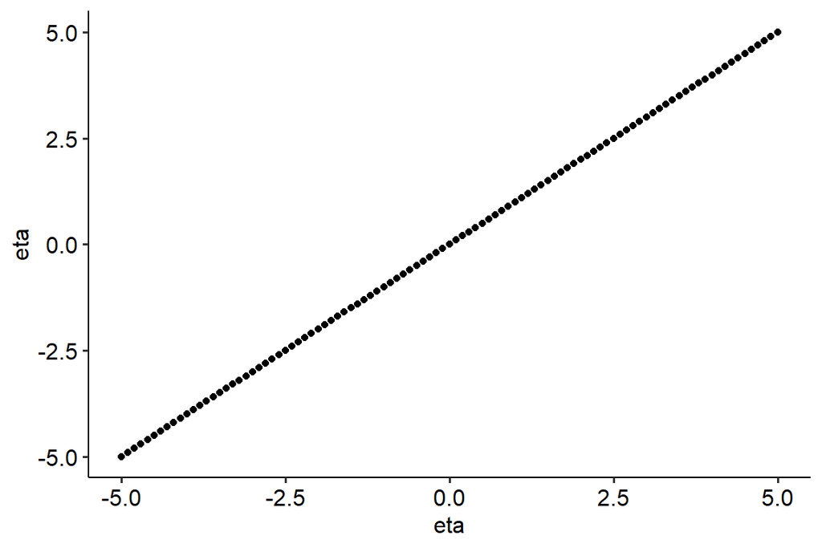

Using the inverse link function, we transform them to again fall > 0.

Fig 2b. Linear predictor (log scale) against average counts

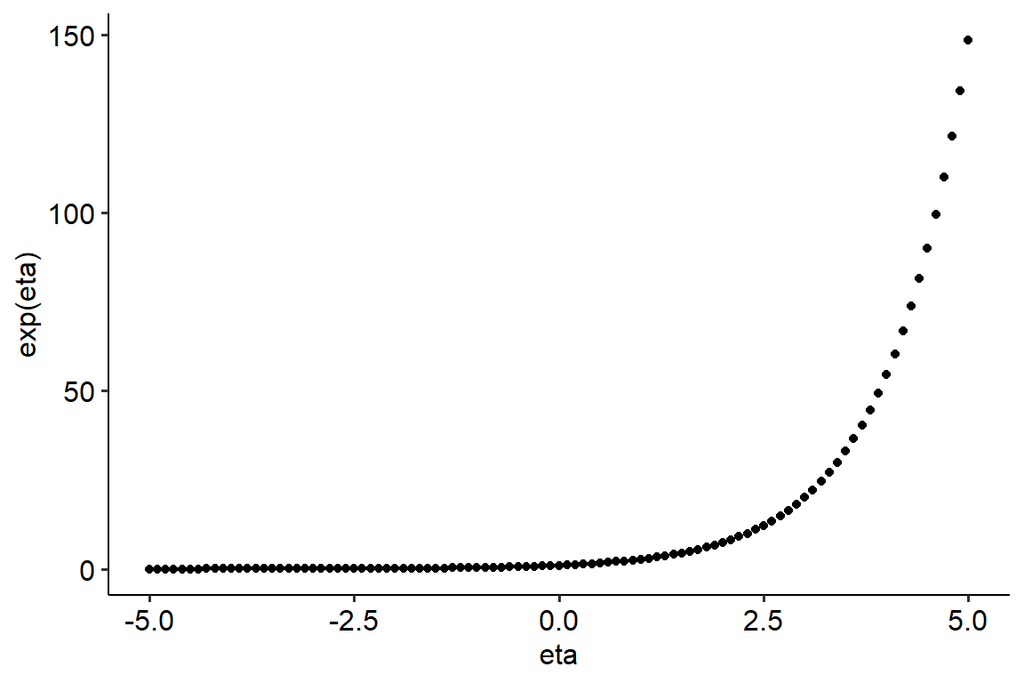

## 3.1 Poisson Regression Assumptions

Much like a normal distribution was assumed for normal linear regression, for poisson regression a poisson distribution is assumed.

$$y \sim Pois(\lambda)$$

In poisson regression although for relatively less common outcomes, outliers on the left hand side may not be a concern, large positive outliers (e.g., someone with an extreme number of awards, or who has multiple health appointments daily, etc.) may be a concern.

Outliers on predictors may still be a concern.

Poisson regression still requires that the errors be independent (i.e., individuals are independent, not dependent or repeated measures).

Poisson regression also assumes that on the link scale (natural log scale) there is a linear relationship.

Finally, poisson regression generally requires a large sample size. There are no degrees of freedom so it requires a large enough sample that **parameters** are distributed about normally relying on the central limit theorem.

## 3.2 Poisson Regression in `R`

To estimate a poisson regression in `R`, we can use the `glm()` function which allows us to fit a variety of different GLMs, including poisson regression. `glm()` works almost identically to `lm()`, with a few caveats. The first caveat is that for anything other than a linear model, we need to specify the `family =` argument, which controls which specific type of GLM is estimated. In this case we want a poisson regression, so we use `family = poisson()`.

The second caveat is that although some functions we are used to from working with `lm()` will carry over to working with `glm()` models, many functions will not work or will not work the same way. Because linear regression is the most common, there tend to be the most tools and convenience features implemented for it. In addition, some things, like $R^2$ variance explained that makes sense with linear regression does not really make sense for poisson regression.

The following code fits a poisson regression to the number of awards `num_awards` predicted by math scores, `math`. There is not a single agreed upon way to evaluate the residuals of these models for whether they meet the assumptions, so we may just evaluate the distribution of the outcome to see if it closely fits a poisson distribution. The figure suggests its fairly close, so we might proceed with a summary of the model from `summary()`.

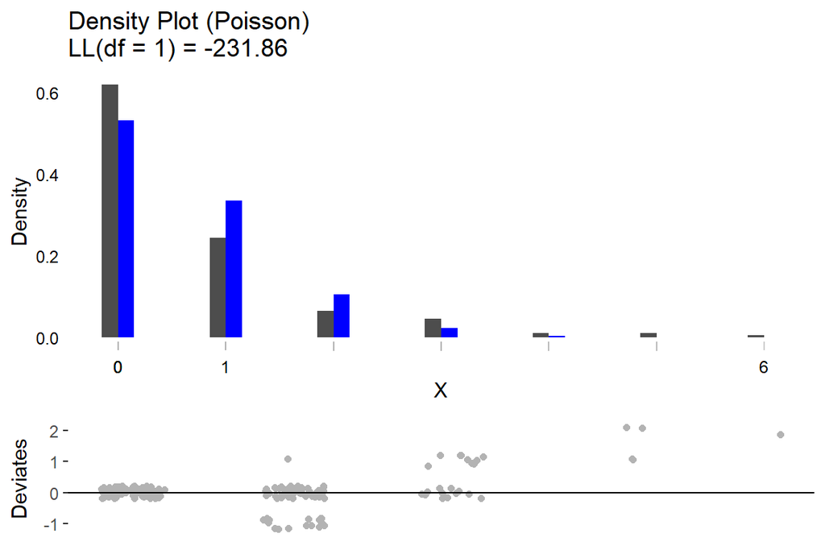

```r
m <- glm(num_awards ~ math, data = dcount, family = poisson())

plot(testDistribution(dcount$num_awards, distr = "poisson"))
```

```r
summary(m)
```

```
##
## Call:
## glm(formula = num_awards ~ math, family = poisson(), data = dcount)
##
## Deviance Residuals:
##    Min      1Q  Median      3Q     Max
## -2.185  -0.907  -0.600   0.325   2.953
##
## Coefficients:
##             Estimate Std. Error z value Pr(>|z|)
## (Intercept) -5.33353    0.59126   -9.02   <2e-16 ***
## math         0.08617    0.00968    8.90   <2e-16 ***
## ---
## Signif. codes:  0 '***' 0.001 '**' 0.01 '*' 0.05 '.' 0.1 ' ' 1
##
## (Dispersion parameter for poisson family taken to be 1)
##
##     Null deviance: 287.67  on 199  degrees of freedom
## Residual deviance: 204.02  on 198  degrees of freedom
## AIC: 384.1
##
## Number of Fisher Scoring iterations: 6
```

The output from `summary(m)` is fairly similar to what we would see for a linear regression in `R`.

- Deviance Residuals: these still represent model residuals, but they are no longer raw residuals defined as $y - \hat{y}$. Deviance residuals are how much each data point contributed to the residual deviance, a sort of measure of overall model fit. They are analogous to residuals in linear regression, in that when you sum and square these residuals, you get the sums of squares used to assess model fit. They differ in that they are not calculated as the raw difference between each data point and the predicted value.
- Coefficients: the coefficients table is interpretted nearly identically as in linear regression. The estimates are the regression coefficients, the standard errors are given next. Instead of t values, z values are presented because in general for GLMs we cannot calculate degrees of freedom so we rely on the central limit theory, and so instead of a t-test, we use a z-test (recall from early stats that with an infinite sample size, the t-distribution becomes identical to the normal distribution and thus the t-test and z-test are the same, with an infinite sample and they are functionally the same with a relatively large sample). P values are in the final column, now based of the z-test instead of the t-tests used in linear regression.
- There is no model $R^2$ as that only works clearly for linear regression. Instead, we get null and residual deviance values and an AIC, which stands for the Akaike Information Criterion, a relative measure of model fit taking into account model complexity. We’ll learn more about this much later in the semester, for now you don’t need to worry about them.
- The number of Fisher scoring iterations. This is included because unlike linear regression where we can directly calculate the best parameter estimates. For other GLMs, the computer tries different values and finds the best values, in a process known as optimization. At each step of the optimization it evaluates how well the specific parameter estimates work and based on some criteria whether to keep trying for better estimates or stop trying. Each one of these steps is called an “iteration” and the number of iterations can give a rough sense of how hard it was for the computer to find the values. Again you can mostly ignore these for now, although it will become more important as we talk about mixed effects models.

### 3.2.1 Poisson Regression Interpretation

At one level, we can interpret the coefficients for poisson regression nearly identically to those for linear regression, as long as we use the log scale. An example follows.

A poisson regression predicting the number of awards each student received from their math scores showed that students who had a 0 math score were expected to have -5.33 log awards, p < .001. Each one unit higher math score was associated with 0.09 higher log awards, p < .001. A graph of these results follows.

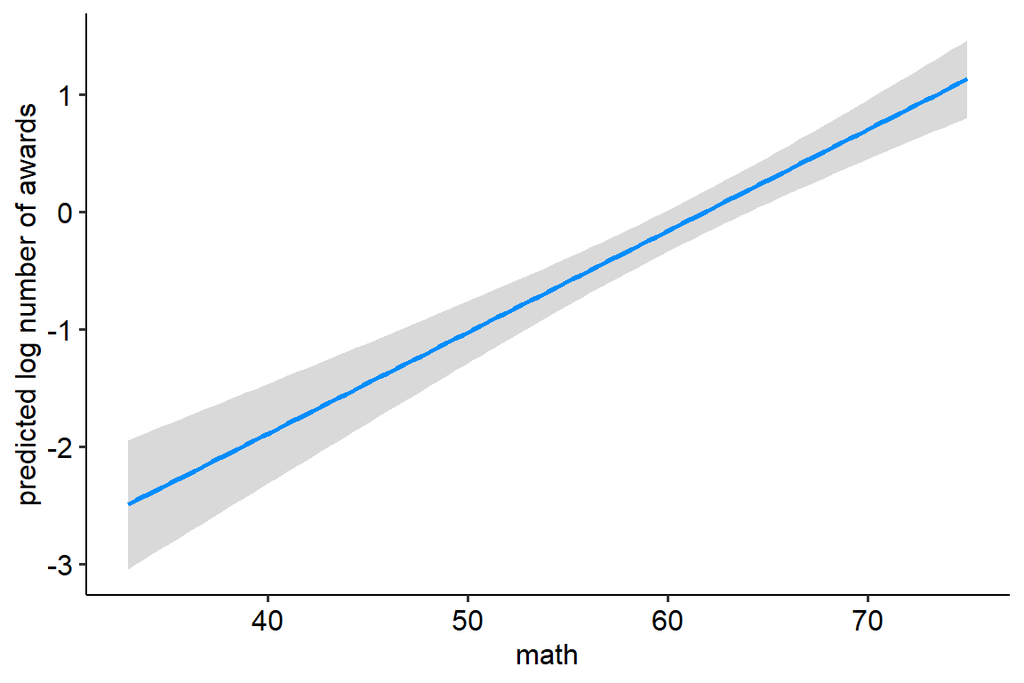

```r
visreg(m, xvar = "math", partial = FALSE, rug = FALSE, gg = TRUE) +
  ylab("predicted log number of awards") +
  theme_pubr()
```

By specifying that we are working on a log scale, we can interpret the results as we did before and graph the results almost the same as before, other than needing to mention the log. Although these interpretations are technically accurate, for most people, it is hard to understand results on a log scale.

If we exponentiate the regression coefficients, specifically the slopes, we get what are called **Incident Rate Ratios** or IRRs. IRRs indicate how many more times the outcome will be for a one unit change in the predictor. For example, if the $IRR = 2$ and the base rate was 1, then one unit higher would be $1 * 2 = 2$. If the base rate was 2, then a one unit higher would be $2 * 2 = 4$. IRRs are interpretted as for each one unit higher predictor score, there are IRR times as many events of the outcome. Because IRRs are multiplicative, an IRR of 1 means that a one unit change in the predictor is associated with 1 times as many events on the outcome, that is no change. Thus on the IRR scale, a coefficient of 1 is equivalent to a coefficient of 0 on the link (log) scale.

Note that although we can exponentiate coefficients, confidence intervals, or predictions, we should *not* exponentiate standard errors, z values or p values. To get the IRRs in `R`, we can extract the coefficients from the model using the `coef()` function and then exponentiate using the `exp()` function and we follow a nearly identical process for the confidence intervals.

```r
exp(coef(m))
```

```
## (Intercept)        math
##     0.00483     1.08999
```

```r
exp(confint(m))
```

```
##               2.5 % 97.5 %
## (Intercept) 0.00147  0.015
## math        1.06970  1.111
```

We can interpret poisson regression using the IRRs as follows.

A poisson regression predicting the number of awards each student received from their math scores showed that students who had a 0 math score were expected to have 0.00 awards, [95% CI 0.00 - 0.01]. Each one unit higher math score was associated with having 1.09 times the number of awards, [95% CI 1.07 - 1.11], p < .001. A graph of these results follows.

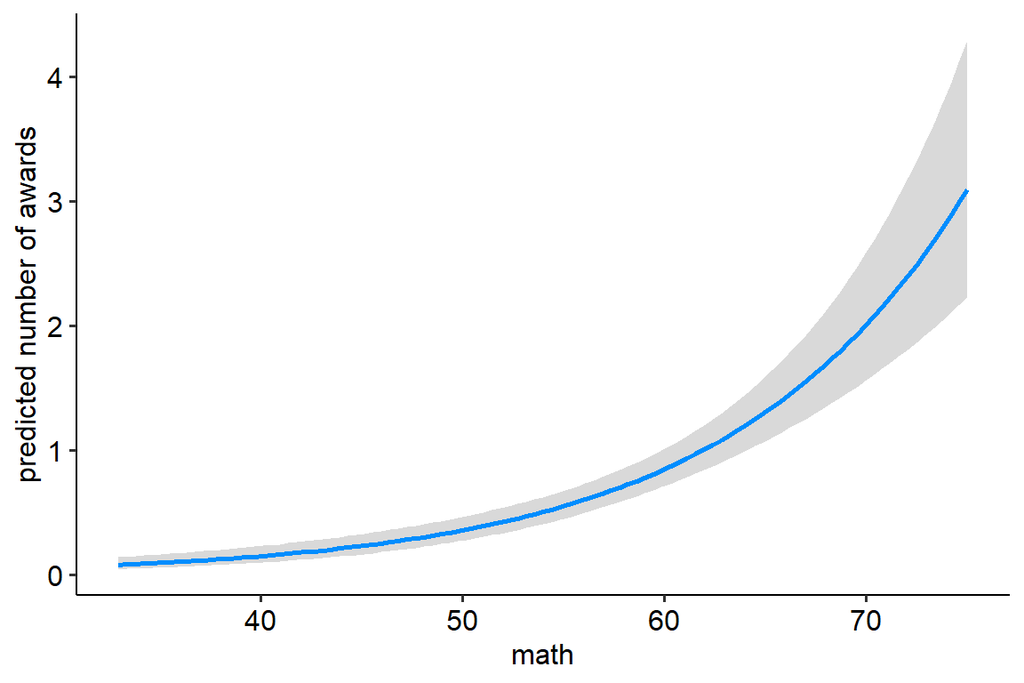

```r
visreg(m, xvar = "math", scale = "response",
       partial = FALSE, rug = FALSE, gg = TRUE) +
  ylab("predicted number of awards") +
  theme_pubr()
```

Note that when calling `visreg()`, we added the new argument, `scale = "response"`. This tells `R` that we do not want the results on the linear link scale, we want them on the original response scale. This argument for `visreg()` is helpful any time you are working with non linear link functions. The figure also shows how although on the link scale there was a perfectly linear model prediction, the linear model on the original response scale is clearly not linear.

Poisson regression with multiple predictors follows the same interpretation, but just as with linear regression you need to specify that what is being evaluated is the unique / independent association of each predictor with the outcome, independent of other variables in the model.

### 3.2.2 You Try It - Poisson

There is no association between prog and num_awards so do not be surprised if the graphs etc are not that interesting.

Fit a poisson regression predicting the number of awards, `num_awards` from `prog` in the `dcount` data. Try to interpret the results using IRRs and make a graph.

```r
## fit poisson regression

## calculate IRRs and confidence intervals on the IRR scale

## graph and visualize the results
```

# 4 Binary Logistic Regression

Binary logistic regression is regression when the outcome only takes on two values: 0 or 1. Logistic regression is useful for many questions, such as:

- What predicts whether someone will have major depression or not?
- Does one treatment have a higher probability of patients *remitting* from major depression than another treatment?
- What is the probability that a patient will be re-admitted to the hospital within 30 days of discharge?
- What predicts whether an individual will live or die before age 60?
- If a bank gives a loan to someone, what is their probability of not being able to pay it back?
- Do older adults have a higher probability of using CAM than younger adults?

Linear regression will not work for binary outcomes for two reasons:

- First, when an outcome can only be 0 or 1, a straight line is a very bad fit
  - straight lines could predict a value of 1.4 or 2 or -0.3 when those values are not possible
- Second, there is no way that a binary variable or its residuals will follow a normal distribution: the normality assumption would be violated

The GLM solves each of these problems separately

- Link functions transform the linear predicted value $\eta$ so that it never goes below 0 and never goes about 1
- Rather than assume a normal distribution, the GLM uses a new distribution, the Bernoulli distribution
  - Whereas the Normal distribution had two parameters, mean and standard deviation, the Bernoulli distribution only has one: the average probability that an event will occur, sometimes $p$ or $\mu$

For logistic regression, the link function is defined as:

$$\eta = g(\mu) = ln\left(\frac{\mu}{1 - \mu}\right)$$

That is called the *logit* function.

Here $\mu$ is the probability that the outcome will be 1. Probabilities range from 0 to 1: an outcome cannot happen less than never (probability of 0) or more than always (probability of 1).

Graphing $\mu$ against $\mu$ we get

Fig 1a. Probabilities against Probabilities

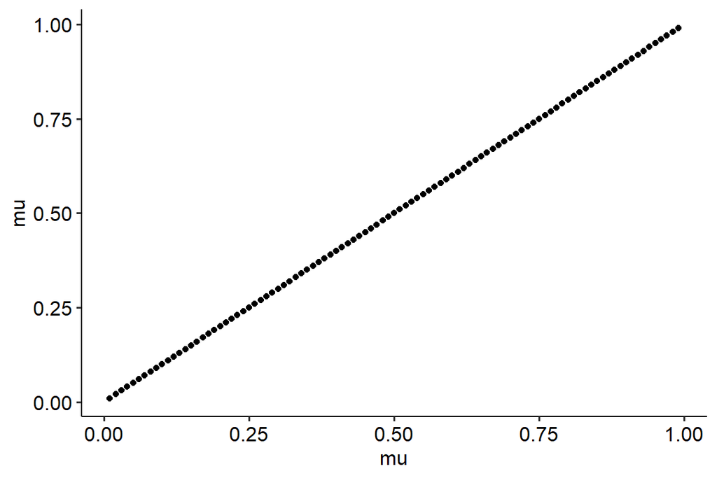

The first part of the *logit* function:

- $\frac{\mu}{1 - \mu}$

unbounds $\mu$ on the right side, so that as it goes to 1, transformed, it goes to infinity, shown graphically below

Fig 1b. Probabilities against right unbounded probabilities

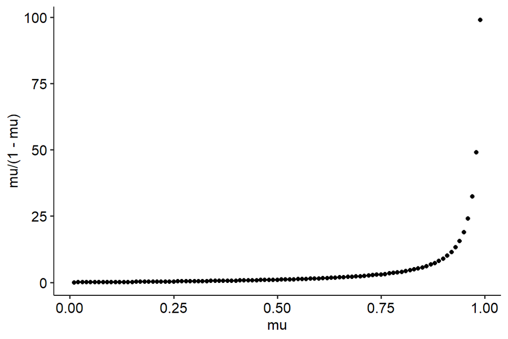

The next part, the natural logarithm, unbounds it on the left side because the log of 0 is negative infinity

- $ln\left(\frac{\mu}{1 - \mu}\right)$

Combined, the graph below shows the raw $\mu$ values against the transformed values.

Fig 1c. Probabilities against unbounded probabilities (logit scale)

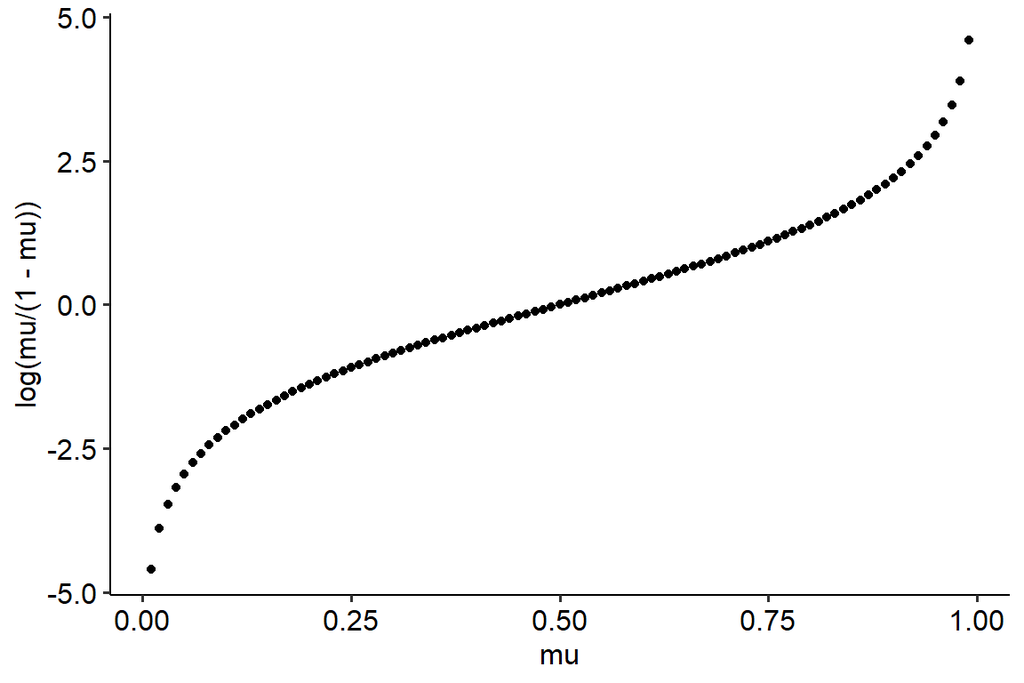

In this way, the link function for logistic regression takes the probability of the event occuring, which can only fall between 0 and 1, and transforms it to fall between negative infinity and positive infinity

Now we have a continuous and unbounded outcome we can apply a linear model to!

To go from predictions on the linear model back to the probability scale, we use the inverse link function:

$$\mu = g^{-1}(\eta) = \frac{1}{1 + e^{-\eta}}$$

That is, suppose we had the linear predicted values, $\eta$ shown below graphically

Fig 2a. Linear predictor against linear predictor

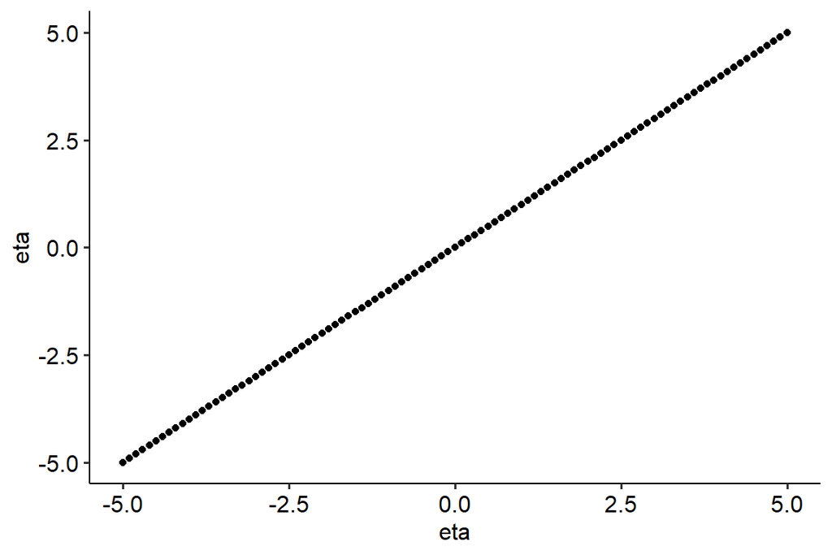

Using the inverse link function, we transform them to again fall between 0 and 1, like probabilities.

Figure 2b. Linear predictor (logit scale) against probabilities

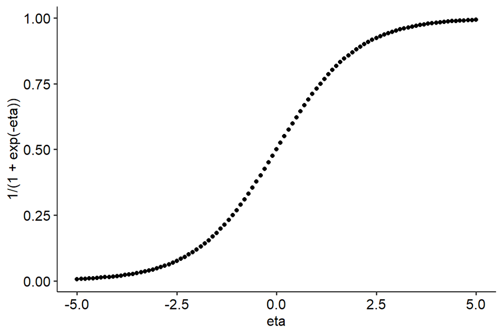

## 4.1 Logistic Regression Assumptions

Much like a normal distribution was assumed for normal linear regression, for logistic regression a Bernoulli distribution is assumed.

$$y \sim Bern(\mu)$$

The Bernoulli only has the one parameter, the probability of the event occuring.

In logistic regression the outcome is either 0 or 1, so outliers on the outcome are not a concern

Outliers on predictors may still be a concern

One problem that sometimes arises is known as separation, this occurs when some predictor perfectly predicts the outcome or separates the outcome, most often when the outcome is rare or the sample size is small.

- In a sample of 60 people where only 10 have major depression, if 80% of the sample also have PTSD, it may happen that all cases of major depression occurred in people with PTSD, so the percentage of depression in those without PTSD is exactly 0%, which is separation.
- The usual solution is to remove predictors or collapse groups in these cases

Logistic regression still requires that the errors be independent (i.e., individuals are independent, not dependent or repeated measures).

Logistic regression also assumes that on the linke scale (logit scale) there is a linear relationship.

Finally, logistic regression generally requires a large sample size. There are no degrees of freedom, requires large enough sample that parameters are distributed about normally (central limit theorem).

## 4.2 Logistic Regression in `R` 1

For logistic regression in `R`, we will use the `StressHigh` categorical variable we created based off stress scores in the baseline data collection exercise data.

First, let’s take a look at some basic descriptives on a few variables we will work with. The `egltable()` function calculates basic descriptive estimates optionally by group levels in a table. The first argument is a list of variable names and then we give it a dataset. The argument `strict=FALSE` is used to indicate that if a variable has few levels, like `StressHigh` which is only 0 and 1, even though `R` stores it as a continuous variable, it should be treated as categorical for the table, otherwise `egltable()` will report means instead of frequencies unless the variable is a string or factor variable.

```r
egltable(
  c("StressHigh", "stress", "SelfesteemHigh", "selfesteem"),
  data = db, strict=FALSE)
```

```
##                   M (SD)/N (%)
## 1:     StressHigh
## 2:              0    40 (70.2)
## 3:              1    17 (29.8)
## 4:         stress 27.44 (5.54)
## 5: SelfesteemHigh
## 6:              0    25 (43.9)
## 7:              1    32 (56.1)
## 8:     selfesteem 13.82 (3.23)
```

```r
egltable(
  c("stress", "SelfesteemHigh", "selfesteem"),
  g = "StressHigh",
  data = db, strict=FALSE)
```

```
##                   0 M (SD)/N (%) 1 M (SD)/N (%)
## 1:         stress   24.50 (3.31)   34.35 (2.87)
## 2: SelfesteemHigh
## 3:              0      11 (27.5)      14 (82.4)
## 4:              1      29 (72.5)       3 (17.6)
## 5:     selfesteem   14.95 (2.52)   11.18 (3.23)
##                                                Test
## 1:            t(df=55) = -10.67, p < .001, d = 3.09
## 2: Chi-square = 14.58, df = 1, p < .001, Phi = 0.51
## 3:
## 4:
## 5:              t(df=55) = 4.75, p < .001, d = 1.37
```

As with poisson regression, we can fit a logistic regression using the `glm()` function. We use the usual regression formula approach, specify the dataset and set `family = binomial()`, which gives us a logistic regression.

```r
mlog <- glm(StressHigh ~ SelfesteemHigh, data = db, family = binomial())

summary(mlog)
```

```
##
## Call:
## glm(formula = StressHigh ~ SelfesteemHigh, family = binomial(),
##     data = db)
##
## Deviance Residuals:
##    Min      1Q  Median      3Q     Max
## -1.281  -0.444  -0.444   1.077   2.176
##
## Coefficients:
##                Estimate Std. Error z value Pr(>|z|)
## (Intercept)       0.241      0.403    0.60  0.54947
## SelfesteemHigh   -2.510      0.728   -3.45  0.00057 ***
## ---
## Signif. codes:  0 '***' 0.001 '**' 0.01 '*' 0.05 '.' 0.1 ' ' 1
##
## (Dispersion parameter for binomial family taken to be 1)
##
##     Null deviance: 69.468  on 56  degrees of freedom
## Residual deviance: 54.209  on 55  degrees of freedom
## AIC: 58.21
##
## Number of Fisher Scoring iterations: 4
```

The output from `summary(mlog)` is fairly similar to what we would see for a linear regression in `R`.

- Deviance Residuals: these still represent model residuals, but they are no longer raw residuals defined as $y - \hat{y}$. Deviance residuals are how much each data point contributed to the residual deviance, a sort of measure of overall model fit. They are analogous to residuals in linear regression, in that when you sum and square these residuals, you get the sums of squares used to assess model fit. They differ in that they are not calculated as the raw difference between each data point and the predicted value.
- Coefficients: the coefficients table is interpretted nearly identically as in linear regression. The estimates are the regression coefficients, the standard errors are given next. Instead of t values, z values are presented because in general for GLMs we cannot calculate degrees of freedom so we rely on the central limit theory, and so instead of a t-test, we use a z-test (recall from early stats that with an infinite sample size, the t-distribution becomes identical to the normal distribution and thus the t-test and z-test are the same, with an infinite sample and they are functionally the same with a relatively large sample). P values are in the final column, now based of the z-test instead of the t-tests used in linear regression.
- There is no model $R^2$ as that only works clearly for linear regression. Instead, we get null and residual deviance values and an AIC, which stands for the Akaike Information Criterion, a relative measure of model fit taking into account model complexity. We’ll learn more about this much later in the semester, for now you don’t need to worry about them.
- The number of Fisher scoring iterations. This is included because unlike linear regression where we can directly calculate the best parameter estimates. For other GLMs, the computer tries different values and finds the best values, in a process known as optimization. At each step of the optimization it evaluates how well the specific parameter estimates work and based on some criteria whether to keep trying for better estimates or stop trying. Each one of these steps is called an “iteration” and the number of iterations can give a rough sense of how hard it was for the computer to find the values. Again you can mostly ignore these for now, although it will become more important as we talk about mixed effects models.

### 4.2.1 Logistic Regression Interpretation

At one level, we can interpret the coefficients for logistic regression nearly identically to those for linear regression, as long as we use the logit scale. An example follows.

A logistic regression predicting high stress from selfesteem (high / low) showed that students who had low selfesteem were expected to have 0.24 log odds of being high stress, p = .549. Being in the high versus low selfesteem group was associated with -2.51 lower log odds of being high stress, p < .001. A graph of these results follows.

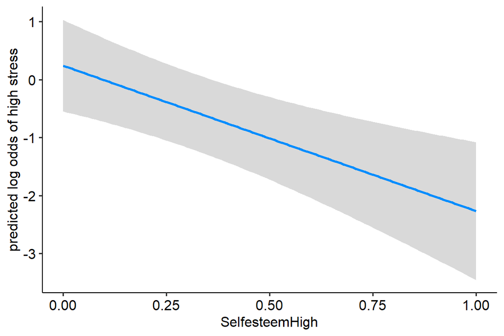

```r
visreg(mlog, xvar = "SelfesteemHigh", partial = FALSE, rug = FALSE, gg = TRUE) +
  ylab("predicted log odds of high stress") +
  theme_pubr()
```

By specifying that we are working on the log odds (logit) scale, we can interpret the results as we did before and graph the results almost the same as before, other than needing to mention the log odds. Although these interpretations are technically accurate, for most people, it is hard to understand results on a log odds scale.

If we exponentiate the regression coefficients, specifically the slopes, we get what are called **Odds Ratios** or ORs. ORs indicate how many more times the odds of occuring the outcome will be for a one unit change in the predictor. For example, if the $OR = 2$ and the base odds was 0.5, then one unit higher would be $0.5 * 2 = 1$ odds. If the base odds was 2, then a one unit higher would be $2 * 2 = 4$ odds. ORs are interpretted as for each one unit higher predictor score, there are OR times the odds of the outcome. Because ORs are multiplicative, an OR of 1 means that a one unit change in the predictor is associated with 1 times the odds of the outcome, that is no change. Thus on the OR scale, a coefficient of 1 is equivalent to a coefficient of 0 on the link (log odds) scale.

Note that although we can exponentiate coefficients, confidence intervals, or predictions, we should *not* exponentiate standard errors, z values or p values. To get the ORs in `R`, we can extract the coefficients from the model using the `coef()` function and then exponentiate using the `exp()` function and we follow a nearly identical process for the confidence intervals.

```r
exp(coef(mlog))
```

```
##    (Intercept) SelfesteemHigh
##         1.2727         0.0813
```

```r
exp(confint(mlog))
```

```
##                 2.5 % 97.5 %
## (Intercept)    0.5791  2.869
## SelfesteemHigh 0.0163  0.304
```

We can interpret logistic regression using the ORs as follows.

A logistic regression predicting high stress from selfesteem (high / low) showed that students who had low selfesteem were expected to have 1.27 odds of being high stress, [95% CI 0.58 - 2.87]. Being in the high vs low self esteem group was associated with 0.08 times the odds of being high stress, [95% CI 0.02 - 0.30], p < .001. A graph of these results follows.

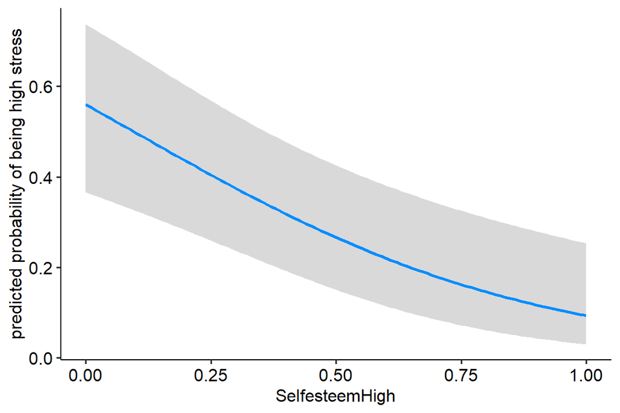

```r
visreg(mlog, xvar = "SelfesteemHigh", scale = "response",
       partial = FALSE, rug = FALSE, gg = TRUE) +
  ylab("predicted probability of being high stress") +
  theme_pubr()
```

Note that when calling `visreg()`, we added the new argument, `scale = "response"`. This tells `R` that we do not want the results on the linear link scale, we want them on the original response scale. This argument for `visreg()` is helpful any time you are working with non linear link functions. The figure also shows how although on the link scale there was a perfectly linear model prediction, the linear model on the original response scale is clearly not linear.

Logistic regression with multiple predictors follows the same interpretation, but just as with linear regression you need to specify that what is being evaluated is the unique / independent association of each predictor with the outcome, independent of other variables in the model.

In addition to the odds ratio (OR) scale, with a simple model, we can easily convert from the logit scale to the probability scale, which may be even easier to interpret.

People with lower self esteem are the reference group, captured by the intercept

$$\frac{1}{1 + e^{- (0.241)}} = 0.56$$

People with lower self esteem have a 0.56 probability of being high stress

The coefficient for self esteem, indicates that people with high self esteem have -2.51 higher log odds (the logit scale) of being high stress than do people with low self esteem.

To calculate the probability that people with high self esteem will be high stress:

$$\frac{1}{1 + e^{- (0.241 + -2.51)}} = 0.094$$

People with high self esteem have a 0.094 probability of being high stress

Stated on the the odds scale.

- People with high self esteem have $e^{-2.51} = 0.081$ times the odds of being high stress as do people with low self esteem
- This is called the odds ratio (OR)

An example summary of this analysis is: “People with high self esteem were less likely to be high stress than people with low self esteem, (OR = 0.081, p < .001).”

Another way of saying the same thing: “People with high self esteem had 0.081 times the odds of being high stress as people with low self eseteem (p < .001).”

## 4.3 Logistic Regression in `R` 2

Next we examine a continuous predictor, continuous self esteem. The analysis in `R` is basically the same as the previous example:

```r
mlog2 <- glm(StressHigh ~ selfesteem, data = db, family = binomial())

summary(mlog2)
```

```
##
## Call:
## glm(formula = StressHigh ~ selfesteem, family = binomial(), data = db)
##
## Deviance Residuals:
##    Min      1Q  Median      3Q     Max
## -2.539  -0.625  -0.513   0.529   2.046
##
## Coefficients:
##             Estimate Std. Error z value Pr(>|z|)
## (Intercept)    4.898      1.735    2.82  0.00476 **
## selfesteem    -0.429      0.127   -3.37  0.00075 ***
## ---
## Signif. codes:  0 '***' 0.001 '**' 0.01 '*' 0.05 '.' 0.1 ' ' 1
##
## (Dispersion parameter for binomial family taken to be 1)
##
##     Null deviance: 69.468  on 56  degrees of freedom
## Residual deviance: 52.474  on 55  degrees of freedom
## AIC: 56.47
##
## Number of Fisher Scoring iterations: 4
```

- The coefficient for self esteem indicates that for each one unit higher self esteem, people have -0.429 lower log odds of being high stress
- In odds ratios:
  - For each additional unit of self esteem, participants have 0.651 times the odds of being high stress (p < .001).
- One challenge with the odds ratio metric is that it is multiplicative
  - If the baseline odds are 2, then 1.2 times the odds would be 2.4 (an absolute difference of 0.4)
  - If the baseline odds are 4, then 1.2 times the odds would be 4.8 (an absolute difference of 0.8)
- Important to keep this interpretation in mind, odds ratios do not directly indicate the probability of the event occuring, just how many times higher the odds

We can calculate the specific probability of being high stress as we did for categorical self esteem

Probability of being high stress for participants with 0 self esteem

$$\frac{1}{1 + e^{- (4.898)}} = 0.993$$

Participants with 0 self esteem have a 0.993 probability of being high stress.

To calculate the probability of being high stress for participants with a 20 score on self esteem, we first calculate the log odds:

$$4.898 + -0.429 * 20 = -3.677$$

Then we convert the log odds to probabilities:

$$\frac{1}{1 + e^{- (-3.677)}} = 0.025$$

Participants with a score of 20 on self esteem have a 0.025 probability of being high stress. This matches what we can see visually when we use `visreg()` to plot on the probability scale.

```r
visreg(mlog2, xvar = "selfesteem", scale = "response",
       partial = FALSE, rug = FALSE, gg = TRUE) +
  ylab("predicted probability of being high stress") +
  theme_pubr()
```

Probability of being high stress by self esteem level with 95% confidence intervals

[figure not shown]

Although logistic regression models do not have $R^2$ values, there are some fit indices. For example, we could calculate the predicted probabilities for each person and if they are >= .50, classify them as the model predicting high stress and if < .50 classify them as the model predicting low stress. Then we can compare the model predictions to the observed data to calculate the model accuracy.

```r
accdata <- data.table(
  Observed = db$StressHigh,
  Predicted = as.integer(predict(mlog2, type = "response") >= .50))

## quick view of the data
head(accdata)
```

```
##    Observed Predicted
## 1:        0         0
## 2:        0         0
## 3:        0         0
## 4:        0         0
## 5:        0         0
## 6:        0         0
```

```r
## simple frequencies table
xtabs(~ Observed + Predicted, data = accdata)
```

```
##         Predicted
## Observed  0  1
##        0 37  3
##        1  8  9
```

```r
## accuracy is the average number of times predictions match observed
mean(accdata$Observed == accdata$Predicted)
```

```
## [1] 0.807
```

### 4.3.1 Average Marginal Effects

Because the probability scale is easier to interpret than is even the odds ratio scale, people often desire to convert results from logistic regression into probabilities. A challenge on the probability scale is that the results are not linear. For example if looking at the graph of continuous self esteem predicting the probability of being high stress, the probability changes much less when moving from a self esteem score of 4 to 5 then from 10 to 11.

We can see this in practice by using the `predict()` function to generate some predicted probabilities. We make a small new dataset with some particular self esteem values (4, 5, 10, 11) and specify the argument `type = "response"` to get probabilities rather than predicted log odds.

```r
newdata <- data.table(
  selfesteem = c(4, 5, 10, 11))

newdata$Prob <- predict(mlog2,
                        newdata = newdata,
                        type = "response")

knitr::kable(newdata)
```

| selfesteem | Prob |
| --- | --- |
| 4 | 0.960 |
| 5 | 0.940 |
| 10 | 0.648 |
| 11 | 0.545 |

The probabilities show that the predicted probability of being high stress changes very little when moving from 4 to 5 self esteem but quite a bit from 10 to 11. This illustrates a challenge: if you want to talk about how much the probability of being high stress changes for a one unit change in self esteem, it matters where the self esteem scores started.

One principled approach to solving this problem is called the **average marginal effect**. There are two parts to this. A **marginal** effect is the instantaneous effect of change at a particular point. Technically, it is the derivative of the slope for those that helps. Because each participant has their own actual self esteem, each participant also will have their own marginal effect, their own instaneous rate of change in the probability of being high stress for a change in self esteem. The **average** part of average marginal effect is that we can average the marginal effects across all participants in the sample to get an average marginal effect, and this number represents the average change in probability that you would expect if you took a population that looked like our sample and could increase everyone’s self esteem by one unit.

Calculating the average marginal effect is fairly easy.

1. Using the original dataset, generate predicted probabilities for everyone
2. Add a small quantity, $h$ to every self esteem score in the dataset and generate new predicted probabilities
3. Take the difference between the original and new predicted probabilities divided by $h$ so that the differences are per unit change
4. Average all the differences in probabilities

```r
## pick h value for difference, store that in variable h
h <- .01

## make the original dataset
originaldata <- db[, .(selfesteem)]

## make the incrased self esteem dataset (selfesteem + h)
increaseddata <- db[, .(selfesteem = selfesteem + h)]

## calculate original predicted probabilities
originaldata$Prob <- predict(mlog2, newdata = originaldata,
                             type = "response")

## calculate increased predicted probabilities
increaseddata$Prob <- predict(mlog2, newdata = increaseddata,
                              type = "response")

## calculate the difference in probabilities per unit
diffprob <- (increaseddata$Prob - originaldata$Prob) / h

## calculate the average marginal effect
mean(diffprob)
```

```
## [1] -0.0629
```

The average marginal effect shows that on average in our sample, a one unit increase in self esteem predicts a -0.06 decrease in the probability of being high stress.

## 4.4 GLMs with Multiple Predictors

An important consequence of how we have to calculate the entire log odds of being high on stress before we can calculate predicted probabilities for logistic regression or raw counts for poisson regression is that when we move into multiple predictors in GLMs, if we want to calculate predicted values on the original response scale, we must pick values for every variable. That makes it more difficult to create plots of one variable at a time because we must hold other variables at specific values as well.

To better understand this phenomenon, we’ll continue with logistic regression examples. Here we have both continuous self esteem and neuroticism predicting high vs low stress. On the log odds scale, we can see that there is a linear association between self esteem and log odds of being high stress and the lines are parallel at different levels of neuroticism, reflecting our choice that self esteem and neuroticism are two separate predictors and do not interact (no moderation).

```r
mlog3 <- glm(StressHigh ~ selfesteem + neuroticism,
             data = db, family = binomial())

summary(mlog3)
```

```
##
## Call:
## glm(formula = StressHigh ~ selfesteem + neuroticism, family = binomial(),
##     data = db)
##
## Deviance Residuals:
##    Min      1Q  Median      3Q     Max
## -2.388  -0.599  -0.293   0.412   2.374
##
## Coefficients:
##             Estimate Std. Error z value Pr(>|z|)
## (Intercept)   -1.730      2.781   -0.62   0.5339
## selfesteem    -0.368      0.131   -2.80   0.0051 **
## neuroticism    0.750      0.286    2.62   0.0088 **
## ---
## Signif. codes:  0 '***' 0.001 '**' 0.01 '*' 0.05 '.' 0.1 ' ' 1
##
## (Dispersion parameter for binomial family taken to be 1)
##
##     Null deviance: 69.468  on 56  degrees of freedom
## Residual deviance: 42.672  on 54  degrees of freedom
## AIC: 48.67
##
## Number of Fisher Scoring iterations: 6
```

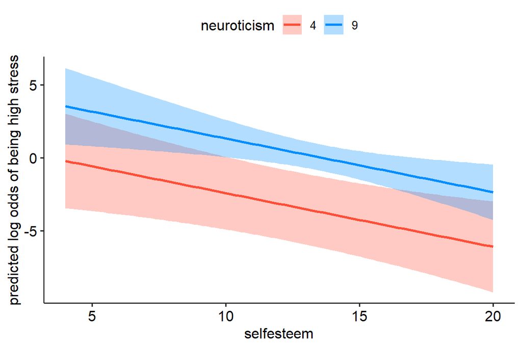

```r
visreg(mlog3, xvar = "selfesteem",
       by = "neuroticism", breaks = c(4, 9),
       scale = "linear", overlay = TRUE,
       partial = FALSE, rug = FALSE, gg = TRUE) +
  ylab("predicted log odds of being high stress") +
  theme_pubr()
```

However, look at what happens when we create the same graph but back convert the predicted log odds into predicted probabilities. In addition to the main effect of neuroticism, the lines no longer appear parallel. On the probability scale, the baseline probability matters and thus neuroticism also influences the “curve” or slope on the probability scale of the association between self esteem and being high stress. For this reason, and the same logic applies to poisson regression, when you have multiple predictors and a non-linear transformation in the link function, all the predictor values influence the final predicted outcome on the original scale.

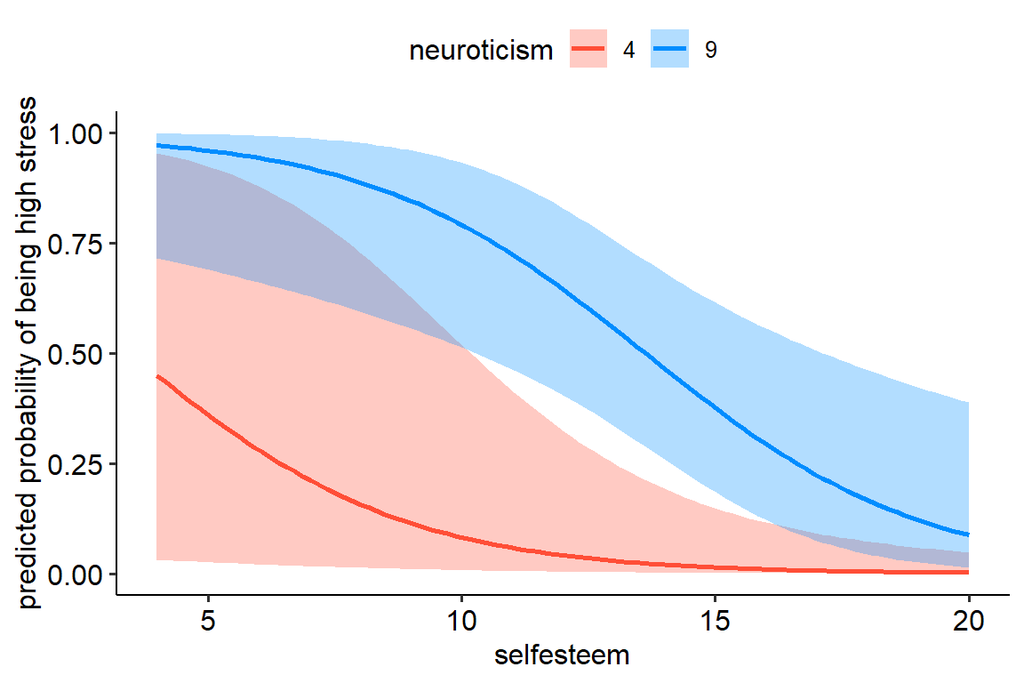

```r
visreg(mlog3, xvar = "selfesteem",
       by = "neuroticism", breaks = c(4, 9),
       scale = "response", overlay = TRUE,
       partial = FALSE, rug = FALSE, gg = TRUE) +
  ylab("predicted probability of being high stress") +
  theme_pubr()
```

When you have multiple predictors it also is possible to calculate average marginal effects for each predictor. The steps are virtually identical to the steps for a single predictor, except that the datasets must include all predictors but you only increase the values of one predictor at a time.

```r
## pick h value for difference, store that in variable h
h <- .01

## make the original dataset
originaldata2 <- db[, .(selfesteem, neuroticism)]

## make the incrased self esteem dataset (selfesteem + h)
increasedSelfEsteem <- db[, .(selfesteem = selfesteem + h, neuroticism)]

## make the incrased neuroticism dataset (neuroticism + h)
increasedNeuro <- db[, .(selfesteem, neuroticism = neuroticism + h)]

## calculate original predicted probabilities
originaldata2$Prob <- predict(mlog3, newdata = originaldata2,
                             type = "response")

## calculate increased predicted probabilities for self esteem
increasedSelfEsteem$Prob <- predict(mlog3, newdata = increasedSelfEsteem,
                              type = "response")

## calculate increased predicted probabilities for neuroticism
increasedNeuro$Prob <- predict(mlog3, newdata = increasedNeuro,
                              type = "response")

## calculate the difference in probabilities per unit
se.diffprob <- (increasedSelfEsteem$Prob - originaldata2$Prob) / h
neuro.diffprob <- (increasedNeuro$Prob - originaldata2$Prob) / h

## calculate the average marginal effect s
mean(se.diffprob) # self esteem
```

```
## [1] -0.0437
```

```r
mean(neuro.diffprob) # neuroticism
```

```
## [1] 0.0889
```

The results show that in the sample, holding neuroticism constant, increasing self esteem by one unit on average is predicted to result in a -0.044 decline in the probability of being high stress. Conversely, holding self esteem constant, increasing neuroticism by one unit on average is predicted to result in a 0.089 increase in the probability of being high stress.

# 5 Summary Table

Here is a little summary of some of the functions used in this topic.

| Function | What it does |
| --- | --- |
| `glm()` | Fits a generalized linear regression model, with `family=poisson()` or `family=binomial()` for poisson and logistic regression |
| `coef()` | Extracts coefficients from a regression model |
| `confint()` | Calculates confidence intervals (95% by default) for a regression model |
| `predict()` | Function to get predicted values from a model, including on the original response scale |
| `testDistribution()` | allows testing a variable against any specific distribution |
| `visreg()` | can be used to make plots of regression models on the linear or original scales |

# 6 Bonus Content

Note: you do not need to read or follow this, it is extra content for those who may use or be interseted.

For binary outcomes, sometimes in place of odds ratios, people prefer to report relative risks. Odds ratios are how many higher times the odds. The relative risk is how many times higher the risk or probability of the event is. To get relative risks, the link function needs to be the natural logarithm. However, this tends to be unstable when used with a bernoulli distribution. The current standard in the literature for binary outcomes to get relative risks is to use a poisson regression model with a log link on the binary outcome. However, it is known that this results in biased standard errors and so it is recommended to use a robust standard errors rather than default standard errors if using a poisson regression to estimate relative risks for a binary outcome. For more examples, see: [here](https://bmcmedresmethodol.biomedcentral.com/articles/10.1186/s12874-018-0519-5).

Robust standard errors can be calculated by using the `survey` package and specifying the IDs for each participant in the model design, which will then have robust standard errors calculated (note, the `survey` package can also handle many other complex survey designs including when people are not randomly selected but were selected based off particular probabilities, but we are only using it here to get the robust standard errors). Then we use the `svyglm()` function which works almost the same as regular `glm()` only it can take the additional `design` argument and can calculate robust standard errors.

```r
## first specify the design, indicating what the ID column is
## the warning about no weights or probabilities is ignorable
design <- svydesign(ids = ~ ID, data = db)
## fit a poisson regression which uses a log link to the binary data
mrr <- svyglm(StressHigh ~ SelfesteemHigh, data = db,
              family = poisson(), design = design)

## get summary of coefficients, standard errors, p-values
## assuming infinite degrees of freedom (central limit theorem)
summary(mrr, df.resid=Inf)
```

```
##
## Call:
## svyglm(formula = StressHigh ~ SelfesteemHigh, design = design,
##     family = poisson(), data = db)
##
## Survey design:
## svydesign(ids = ~ID, data = db)
##
## Coefficients:
##                Estimate Std. Error t value Pr(>|t|)
## (Intercept)      -0.580      0.179   -3.24   0.0012 **
## SelfesteemHigh   -1.787      0.583   -3.07   0.0022 **
## ---
## Signif. codes:  0 '***' 0.001 '**' 0.01 '*' 0.05 '.' 0.1 ' ' 1
##
## (Dispersion parameter for poisson family taken to be 0.714)
##
## Number of Fisher Scoring iterations: 6
```

```r
## calculate the relative risks and confidence intervals
exp(coef(mrr))
```

```
##    (Intercept) SelfesteemHigh
##          0.560          0.167
```

```r
exp(confint(mrr))
```

```
##                 2.5 % 97.5 %
## (Intercept)    0.3944  0.795
## SelfesteemHigh 0.0534  0.524
```

From these results we can say that people with high self esteem have a relative risk of 0.167 of being high stress as do people with low self esteem. In a simple case like this model, that directly means that people with high self esteem have 0.167 times the probability of being high stress as people with low self esteem. Although it is still on the multiplicative scale, it relates to probabilities directly rather than being multiplicative on the odds.